# Practical Machine Learning - Week 1

## Components of a predictor

1. Question
2. Input data
3. Features
4. Algorithm
5. Parameters
6. Evaluation

## Features

```r
library(kernlab)
library(data.table)
library(ggplot2)
```

```r
# load data
data(spam); setDT(spam)
spam
```

```
#>       make address  all num3d  our over remove internet order mail receive
#>    1: 0.00    0.64 0.64     0 0.32 0.00   0.00     0.00  0.00 0.00    0.00
#>    2: 0.21    0.28 0.50     0 0.14 0.28   0.21     0.07  0.00 0.94    0.21
#>    3: 0.06    0.00 0.71     0 1.23 0.19   0.19     0.12  0.64 0.25    0.38
#>    4: 0.00    0.00 0.00     0 0.63 0.00   0.31     0.63  0.31 0.63    0.31
#>    5: 0.00    0.00 0.00     0 0.63 0.00   0.31     0.63  0.31 0.63    0.31
#>   ---
#> 4597: 0.31    0.00 0.62     0 0.00 0.31   0.00     0.00  0.00 0.00    0.00
#> 4598: 0.00    0.00 0.00     0 0.00 0.00   0.00     0.00  0.00 0.00    0.00
#> 4599: 0.30    0.00 0.30     0 0.00 0.00   0.00     0.00  0.00 0.00    0.00
#> 4600: 0.96    0.00 0.00     0 0.32 0.00   0.00     0.00  0.00 0.00    0.00
#> 4601: 0.00    0.00 0.65     0 0.00 0.00   0.00     0.00  0.00 0.00    0.00
#>       will people report addresses free business email  you credit your
#>    1: 0.64   0.00   0.00      0.00 0.32     0.00  1.29 1.93   0.00 0.96
#>    2: 0.79   0.65   0.21      0.14 0.14     0.07  0.28 3.47   0.00 1.59
```

[output cut: 69 more lines]

```r
set.seed(333)
```

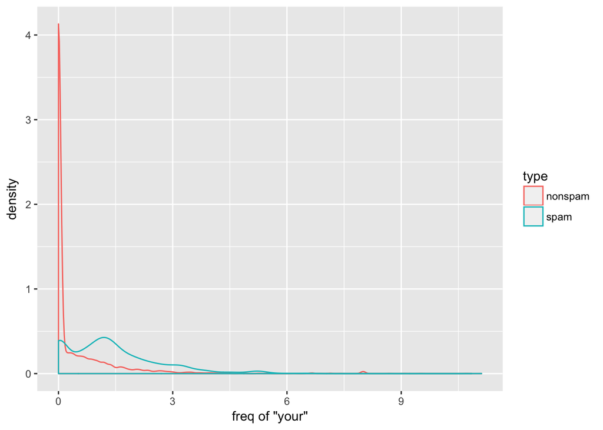

```r
ggplot(spam, aes(your, colour = type)) +
  geom_density() +
  scale_x_continuous(name = 'freq of "your"')
```

## Algorithm

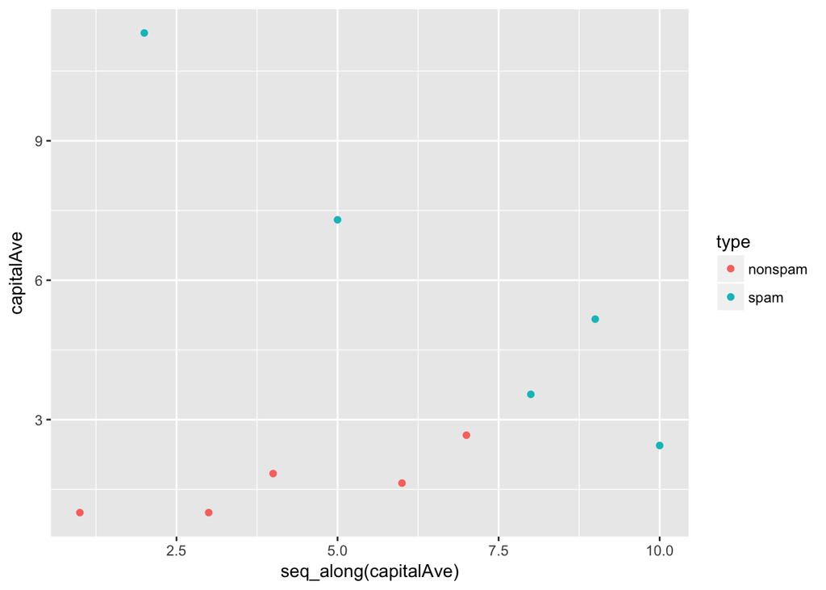

```r
# picking a small subset (10 values) from spam data set
rows <- sample(1:nrow(spam), size=10, replace = F)
spam_small <- spam[rows, ]

# label spam = 2 and ham = 1
spam_label <- (spam_small$type=="spam") * 1 + 1

# plot the capitalAve values for the dataset with colors differentiated by spam/ham (2 vs 1)
ggplot(spam_small,
       aes(x = seq_along(capitalAve), y = capitalAve, colour = type)) +
  geom_point()
```

first rule (over-fitting to capture all variation)

```r
rule1 <- function(x) {
  prediction <- rep(NA,length(x))
  prediction[x > 2.7] <- "spam"
  prediction[x < 2.40] <- "nonspam"
  prediction[(x >= 2.40 & x <= 2.45)] <- "spam"
  prediction[(x > 2.45 & x <= 2.70)] <- "nonspam"
  return(prediction)
}
```

## Evaluation

```r
# tabulate results of prediction algorithm 1 (in sample error -> no error in this case)
table(rule1(spam_small$capitalAve), spam_small$type)
```

```
#>
#>           nonspam spam
#>   nonspam       5    0
#>   spam          0    5
```

# Quiz 1

### Problem 1.

Which of the following are steps in building a machine learning algorithm?

> Deciding on an algorithm, Creating features, Evaluating the prediction.

### Problem 2.

Suppose we build a prediction algorithm on a data set and it is 100% accurate on that data set. Why might the algorithm not work well if we collect a new data set?

> Our algorithm may be overfitting the training data, predicting both the signal and the noise.

### Problem 3.

> typical sizes for the training and the test sets: 60% in the training set, 40% in the testing set.

### Problem 4.

What are some common error rates for predicting binary variables (i.e. variables with two possible values like yes/no, disease/normal, clicked/didn’t click)?

> Specificity, Sensitivity

### Problem 5.

Suppose that we have created a machine learning algorithm that predicts whether a link will be clicked with 99% sensitivity and 99% specificity. The rate the link is clicked is 1/1000 of visits to a website. If we predict the link will be clicked on a specific visit, what is the probability it will actually be clicked?

> - 100,000 visits => 100 clicks`
> - 99% = sensitivity = TP/(TP+FN) = 99/(99+1) = 99/100
> - 99% specificity =TN/(TN+FP) = 98901/(98901+999) = 98901/99900
> - P(actually clicked|clicked) = TP/(TP+FP) = 99/(99+999) = 9%